# Financial Returns

Karim Abi Fadel

2020-10-06

# 1 Returns of financial stocks

Historical data of stock prices is to used calculate returns, and examine the distribution of returns.

```r
nyse <- read_csv(here::here("data","nyse.csv"))
```

## 1.1 The table and bar plot show the number of companies per sector, in descending order

```r
companies_sector <- nyse %>%
  group_by(sector) %>%
  count() %>%
  arrange(desc(n))

companies_sector
```

```
## # A tibble: 12 x 2
## # Groups:   sector [12]
##    sector                    n
##    <chr>                 <int>
##  1 Finance                  97
##  2 Consumer Services        79
##  3 Public Utilities         60
##  4 Capital Goods            45
##  5 Health Care              45
##  6 Energy                   42
##  7 Technology               40
##  8 Basic Industries         39
##  9 Consumer Non-Durables    31
## 10 Miscellaneous            12
## 11 Transportation           10
## 12 Consumer Durables         8
```

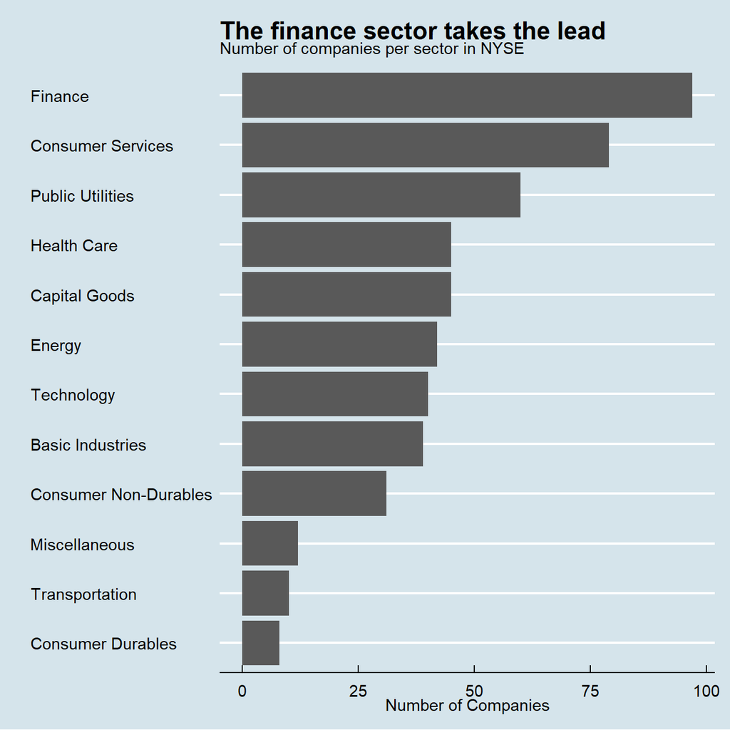

```r
ggplot(companies_sector, aes(x = n, y = reorder(sector, n))) +
  geom_col() +
  labs(title = "The finance sector takes the lead",
       subtitle = "Number of companies per sector in NYSE",
       x = "Number of Companies",
       y = "") +
  theme_economist()
```

## 1.2 Next, the [Dow Jones Industrial Aveareg (DJIA)](https://en.wikipedia.org/wiki/Dow_Jones_Industrial_Average) stocks and their ticker symbols are downloaded. Besides the thirty stocks that make up the DJIA, `SPY` which is an SP500 ETF is downloaded. Let’s have some fun with the new data.

```r
djia_url <- "https://en.wikipedia.org/wiki/Dow_Jones_Industrial_Average"

#get tables that exist on URL
tables <- djia_url %>%
  read_html() %>%
  html_nodes(css="table")


# parse HTML tables into a dataframe called djia.
# Use purr::map() to create a list of all tables in URL
djia <- map(tables, . %>%
               html_table(fill=TRUE)%>%
               clean_names())


# constituents
table1 <- djia[[2]] %>% # the second table on the page contains the ticker symbols
  mutate(date_added = ymd(date_added),

         # if a stock is listed on NYSE, its symbol is, e.g., NYSE: MMM
         # We will get prices from yahoo finance which requires just the ticker

         # if symbol contains "NYSE*", the * being a wildcard
         # then we jsut drop the first 6 characters in that string
         ticker = ifelse(str_detect(symbol, "NYSE*"),
                          str_sub(symbol,7,11),
                          symbol)
         )

# we need a vector of strings with just the 30 tickers + SPY
tickers <- table1 %>%
  select(ticker) %>%
  pull() %>% # pull() gets them as a sting of characters
  c("SPY") # and lets us add SPY, the SP500 ETF
```

```r
myStocks <- tickers %>%
  tq_get(get  = "stock.prices",
         from = "2000-01-01",
         to   = "2020-08-31") %>%
  group_by(symbol)
```

```r
#calculate daily returns
myStocks_returns_daily <- myStocks %>%
  tq_transmute(select     = adjusted,
               mutate_fun = periodReturn,
               period     = "daily",
               type       = "log",
               col_rename = "daily_returns",
               cols = c(nested.col))

#calculate monthly  returns
myStocks_returns_monthly <- myStocks %>%
  tq_transmute(select     = adjusted,
               mutate_fun = periodReturn,
               period     = "monthly",
               type       = "arithmetic",
               col_rename = "monthly_returns",
               cols = c(nested.col))

#calculate yearly returns
myStocks_returns_annual <- myStocks %>%
  group_by(symbol) %>%
  tq_transmute(select     = adjusted,
               mutate_fun = periodReturn,
               period     = "yearly",
               type       = "arithmetic",
               col_rename = "yearly_returns",
               cols = c(nested.col))
```

```r
# Monthly returns since 2017-01-01 for each of the stocks and `SPY`; min, max, median, mean, SD.
summary_of_myStocks_returns_monthly <- myStocks_returns_monthly %>%
  filter(date >= as.Date("2017-01-01")) %>%
  group_by(symbol) %>%
  summarise(min = min(monthly_returns),
            median = median(monthly_returns),
            max = max(monthly_returns),
            mean = mean(monthly_returns),
            std = sqrt(var(monthly_returns)))

summary_of_myStocks_returns_monthly
```

```
## # A tibble: 31 x 6
##    symbol    min   median    max      mean    std
##    <chr>   <dbl>    <dbl>  <dbl>     <dbl>  <dbl>
##  1 AAPL   -0.181  0.0513  0.200   0.0387   0.0873
##  2 AMGN   -0.104  0.0235  0.180   0.0171   0.0664
##  3 AXP    -0.221  0.0150  0.0988  0.0109   0.0639
##  4 BA     -0.458  0.0250  0.257   0.0124   0.120
##  5 CAT    -0.199  0.0318  0.138   0.0151   0.0742
##  6 CRM    -0.155  0.0403  0.391   0.0350   0.0850
##  7 CSCO   -0.155  0.0185  0.130   0.0125   0.0673
##  8 CVX    -0.224  0.00173 0.270  -0.000926 0.0748
##  9 DIS    -0.179 -0.00208 0.234   0.00967  0.0750
## 10 DOW    -0.276  0.0456  0.255   0.00898  0.128
## # ... with 21 more rows
```

## 1.3 Here, you can find a density plot of the monthly returns of each of the stocks

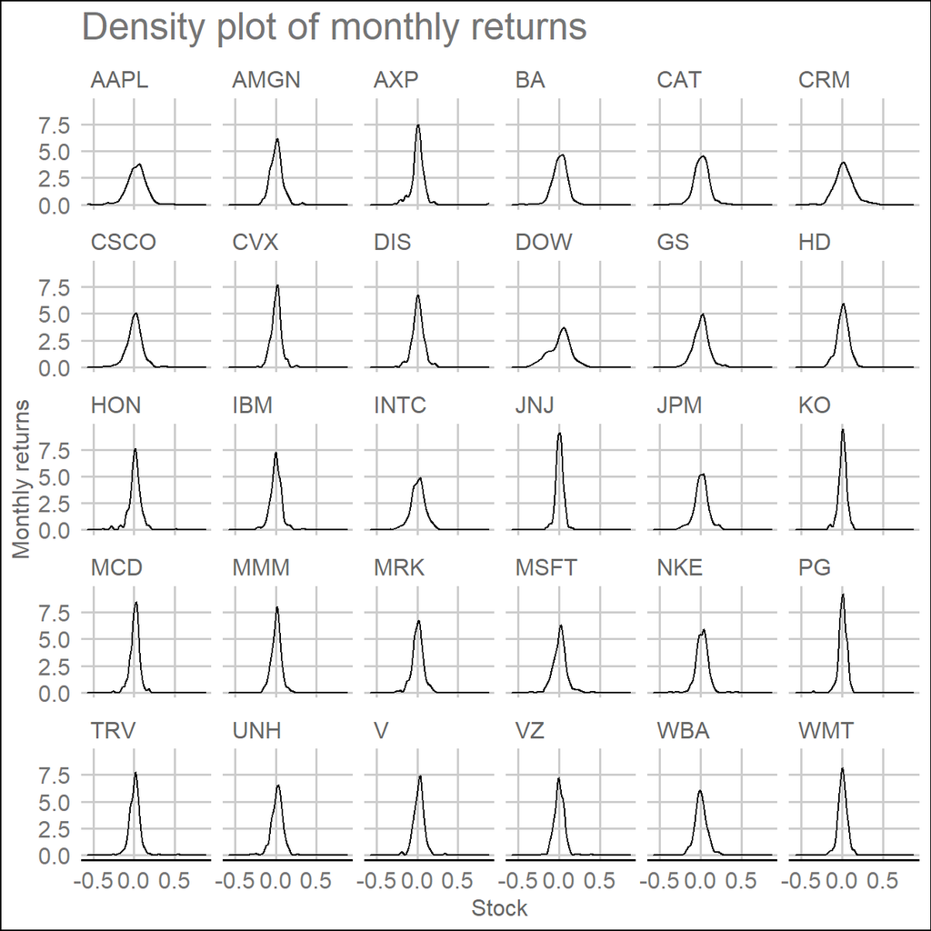

```r
myStocks_returns_monthly %>%
  filter(symbol != "SPY") %>%
  ggplot(aes(x = monthly_returns)) +
  geom_density() +
  labs(title = "Density plot of monthly returns", x = "Stock", y = "Monthly returns") +
  facet_wrap(~symbol) +
  theme_gdocs()
```

> From the plot, we can infer that firms with “wider” curves show more volatility. With that in mind, Coca Cola looks like the least risky firm in the data set as its thin peak represents a smaller deviation in stock movements. On the other hand, Dow Inc comes across as the riskiest stock in the dataset due to its wide peak representing a large deviation in stock prices and thus high volatility.

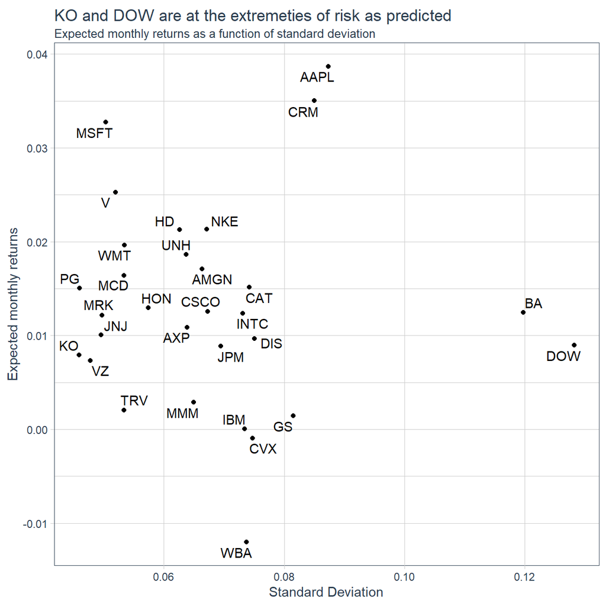

```r
summary_of_myStocks_returns_monthly %>%
  filter(symbol != "SPY") %>%
  ggplot(aes(std, mean, label = symbol)) +
  geom_point() +
  ggrepel::geom_text_repel() +
  labs(title = "KO and DOW are at the extremeties of risk as predicted", subtitle = "Expected monthly returns as a function of standard deviation", x = "Standard Deviation", y = "Expected monthly returns")+
  theme_tq()
```